# SE3. HW2. Suggested Solution

Author

Mykyta Horovoi

## 1. Simulation in R (40% of the HW2 grade)

### 1) Generate stationary AR(p), MA(q) and ARMA(p,q) processes. With $p,q \leqslant 5$

Consider an ARMA(p,q) process of a general form:

$$y_{t} = \beta_1y_{t-1} + \beta_2y_{t-2} + ... + \beta_py_{t-p} + \varepsilon_{t} + \theta_1\varepsilon_{t-1} + ... + \theta_q\varepsilon_{t-q},\ \varepsilon_{t} \sim iddN(0, \sigma^2)\tag{1}$$

In order to reduce code repetitions, create a function that generates ARMA(p,q) processes of any order $p$ and $q$.

```r
# helper function to create lagged matrix of y
lag_mat <- function(y, p) {
  if (p == 0) {
    as.matrix(y)
  } else {
    p <- 1:p
    tmp <- lapply(p, function(i) c(rep(NA,i), head(y, length(y)-i)))
    res <- do.call(cbind, tmp)
    colnames(res) <- paste0("L", p)
    res
  }
}

# function to generate arma(p,q) process
my_arma <- function(ar = NULL, ma = NULL, n = 1000, seed = 1, sd = 1) {
  # set initial values
  lag_ar <- if (is.null(ar)) 0 else length(ar) # set the order of ar process
  lag_ma <- if (is.null(ma)) 0 else length(ma) # set the order of ma process
  lag_bigger <- if (lag_ar > lag_ma) lag_ar else lag_ma # equals to the greatest order of p and q
  n <- n + lag_bigger # number of obs + the greatest order

  set.seed(seed) # set a seed for reproducibility
  epsilon <- rnorm(n = n, mean = 0, sd = sd) # generate errors
  y <- numeric(n) # set a zero-vector for y

  # process generation function
  for (i in ((1+lag_bigger):n)) {
    y[i] <- sum(ar * lag_mat(y, lag_ar)[i,]) + sum(ma * lag_mat(epsilon, lag_ma)[i,]) + epsilon[i]
  }
  y[(1 + lag_bigger):n] # get rid of initial zero values, return ARMA series
}
```

For example, choose $p = 2$ and $q = 2$. Set $\beta_1 = 0.2$, $\beta_2 = 0.5$, $\theta_1 = 0.5$, $\theta_2 = -0.2$.  
For the sake of comparison, coefficient of individual AR an MA processes are chosen to match ones of ARMA process.  
Therefore, the task it to simulate processes $(2)-(4)$:

$$AR(2): y_{t} = 0.2y_{t-1} + 0.5y_{t-2} + \varepsilon_{t} \tag{2}$$

$$MA(2): y_{t} = \varepsilon_{t} + 0.5\varepsilon_{t-1} -0.2\varepsilon_{t-2} \tag{3}$$

$$ARMA(2,2): y_{t} = 0.2y_{t-1} + 0.5y_{t-2} + \varepsilon_{t} + 0.5\varepsilon_{t-1} -0.2\varepsilon_{t-2} \tag{4}$$

$$\varepsilon_{t} \sim iddN(0, 1)\tag{5}$$

Generate series and plot them:

```r
# set parameters
my_ar <- c(0.2, 0.5) # set the order p of ar process
my_ma <- c(0.5, -0.2) # set the order q of ma process
n <- 1000 # number of obs to generate
seed <- 133 # set seed
sd <- 1 # standard deviation of an error term

# generate processes
arma20 <- my_arma(ar = my_ar, n = n, seed = seed, sd = sd) # ar(2)
arma02 <- my_arma(ma = my_ma, n = n, seed = seed, sd = sd) # ma(2)
arma22 <- my_arma(ar = my_ar, ma = my_ma, n = n, seed = seed, sd = sd) # arma(2,2)

# create a plot for AR(2)
p1 <- ggplot(mapping = aes(y = arma20, x = seq(1, n))) +
  geom_line() +
  theme_minimal() +
  labs(title = "Simulated AR(2) process",
       x = "t",
       y = "*y<sub>t</sub>*") +
  theme(axis.title.y = element_markdown())

# create a plot for MA(2)
p2 <- ggplot(mapping = aes(y = arma02, x = seq(1, n))) +
  geom_line() +
  theme_minimal() +
  labs(title = "Simulated MA(2) process",
       x = "t",
       y = "*y<sub>t</sub>*") +
  theme(axis.title.y = element_markdown())

# create a plot for ARMA(2,2)
p3 <- ggplot(mapping = aes(y = arma22, x = seq(1, n))) +
  geom_line() +
  theme_minimal() +
  labs(title = "Simulated ARMA(2) process",
       x = "t",
       y = "*y<sub>t</sub>*") +
  theme(axis.title.y = element_markdown())
```

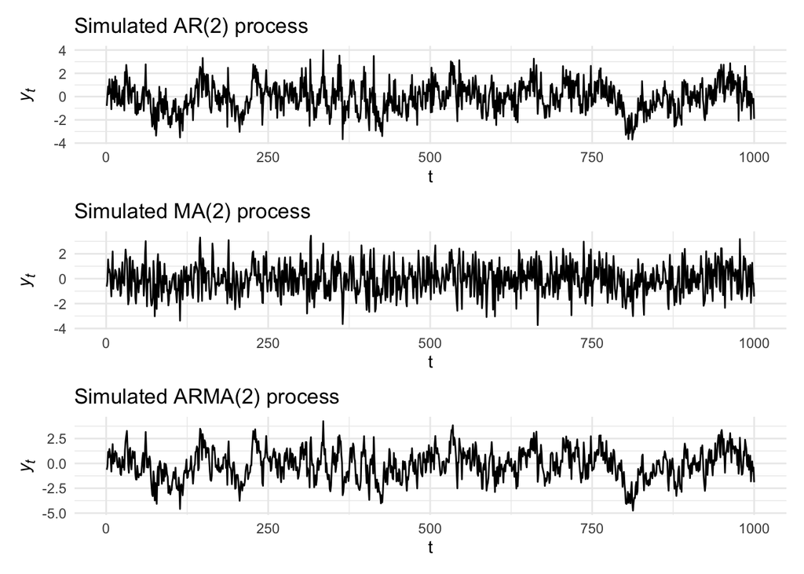

Figure 1: Generated AR(2), MA(2), ARMA(2,2) processes.

```r
# plot generated series with patchwork
p1/p2/p3
```

Write down estimated equations to double-check for a correctness of generation:

```r
mod20 <- arima(arma20, order = c(2,0,0), include.mean = FALSE)
mod02 <- arima(arma02, order = c(0,0,2), include.mean = FALSE)
mod22 <- arima(arma22, order = c(2,0,2), include.mean = FALSE)
```

$$AR(2): \hat{y}_{t} = 0.2290\hat{y}_{t-1} + 0.4570\hat{y}_{t-2} \tag{6}$$

$$MA(2): \hat{y}_{t} = \hat{\varepsilon}_{t} + 0.5028\hat{\varepsilon}_{t-1} -0.2545\hat{\varepsilon}_{t-2} \tag{7}$$

$$ARMA(2,2): \hat{y}_{t} = 0.2668\hat{y}_{t-1} + 0.4783\hat{y}_{t-2} + 0.4330\hat{\varepsilon}_{t-1} -0.2857\hat{\varepsilon}_{t-2} \tag{8}$$

As you can see, the coefficients in $(6)-(8)$ are pretty close to ones in $(2)-(4)$.

### 2) Construct ACFs and PACFs for these processes

First, calculate ACFs and PACFs:

```r
# construct plots
# acf plot
p_acf_ar <- ggAcf(arma20) +
  theme_minimal() +
  labs(title = "ACF AR(2)")

p_acf_ma <- ggAcf(arma02) +
  theme_minimal() +
  labs(title = "ACF MA(2)")

p_acf_arma <- ggAcf(arma22) +
  theme_minimal() +
  labs(title = "ACF ARMA(2,2)")

# pacf plots
p_pacf_ar <- ggPacf(arma20) +
  theme_minimal() +
  labs(title = "PACF AR(2)")

p_pacf_ma <- ggPacf(arma02) +
  theme_minimal() +
  labs(title = "PACF MA(2)")

p_pacf_arma <- ggPacf(arma22) +
  theme_minimal() +
  labs(title = "PACF ARMA(2,2)")
```

Second, plot ACFs and PACFs:

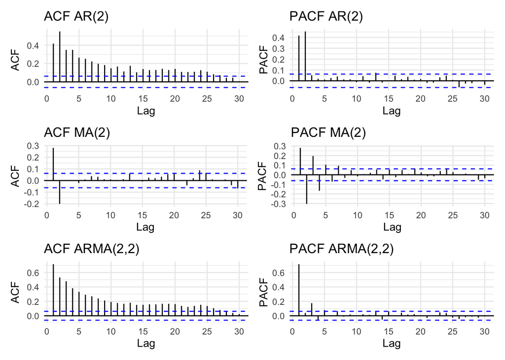

Figure 2: ACFs and PACFs of the generated processes. First plot: ACF decays slowly, PACF cuts off after 2 lags -> AR(2). Second plot: ACF cuts off after 2 lags, PACF decays slowly -> MA(2). Third plot: ACF is from AR(2), PACF is from MA(2) -> ARMA(2,2).

```r
(p_acf_ar + p_pacf_ar)/(p_acf_ma + p_pacf_ma)/(p_acf_arma + p_pacf_arma)
```

## 2. Replication in R (60% of the HW2 grade)

Prepare the data:

- Import `quarterly.xls` data set;
- Transform a string with dates in into `yearquarter` format;
- Convert data frame into a `tsibble` format;
- Filter data to match the range used in the Enders’ textbook (1961 Q4 - 2012 Q4 period);
- Create `spread` variable by subtracting `r5` from `Tbill` .

```r
df <- read_excel("quarterly.xls")
df <- df %>% mutate(DATE = yearquarter(DATE))
df_tsb <- df %>% as_tsibble(index = DATE)
df_model <- df_tsb %>% filter_index("1961 Q4" ~ "2012 Q4")
df_model <- df_model %>% mutate(spread = r5-Tbill)
```

### Replicate Figure 2.5 (p.89)

```r
p_spread <- df_model %>%
  ggplot(aes(x = DATE, y = spread)) +
  geom_line(aes(x = DATE, y = rep(0, nrow(df_model))), color = "grey") +
  geom_line() +
  theme_minimal() +
  labs(title = "Panel a: The interest rate spead",
       x = NULL,
       y = NULL) +
  theme(panel.grid.major = element_blank(),
        axis.line = element_line(colour = "black"),
        plot.title = element_text(hjust = 0.5)) +
  scale_x_yearquarter(expand = c(0, 0))

p_spread_diff <- df_model %>%
  mutate(spread_diff = difference(spread)) %>%
  ggplot(aes(x = DATE, y = spread_diff)) +
  geom_line(aes(x = DATE, y = rep(0, nrow(df_model))), color = "grey") +
  geom_line() +
  theme_minimal() +
  labs(title = "Panel b: First-difference of the spead",
       x = NULL,
       y = NULL) +
  theme(panel.grid.major = element_blank(),
        axis.line = element_line(colour = "black"),
        plot.title = element_text(hjust = 0.5)) +
  scale_x_yearquarter(expand = c(0, 0))
```

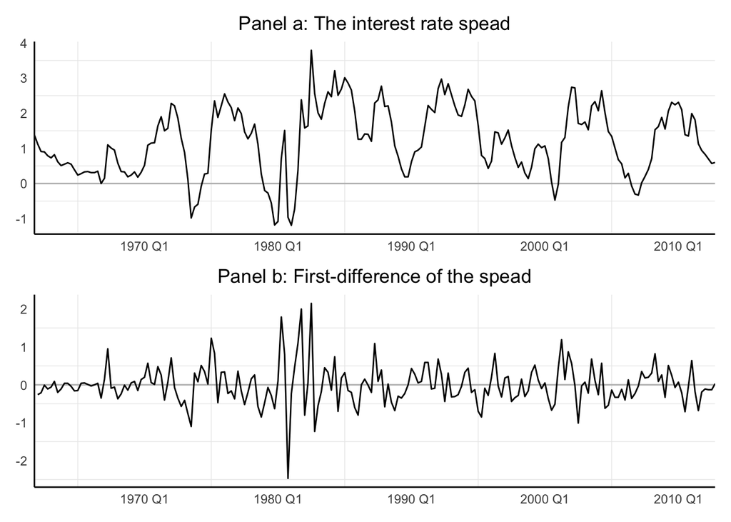

Figure 3: Time path of the Interest Rate Spread.

```r
p_spread/p_spread_diff
```

### Replicate Figure 2.6 (p.89)

```r
# calculate ACF and PACF
p_acf_spread <- ggAcf(df_model$spread, lag.max = 12) +
  theme_minimal() +
  labs(title = "ACF of the Spread")

p_pacf_spread <- ggPacf(df_model$spread, lag.max = 12) +
  theme_minimal() +
  labs(title = "PACF of the Spread")
```

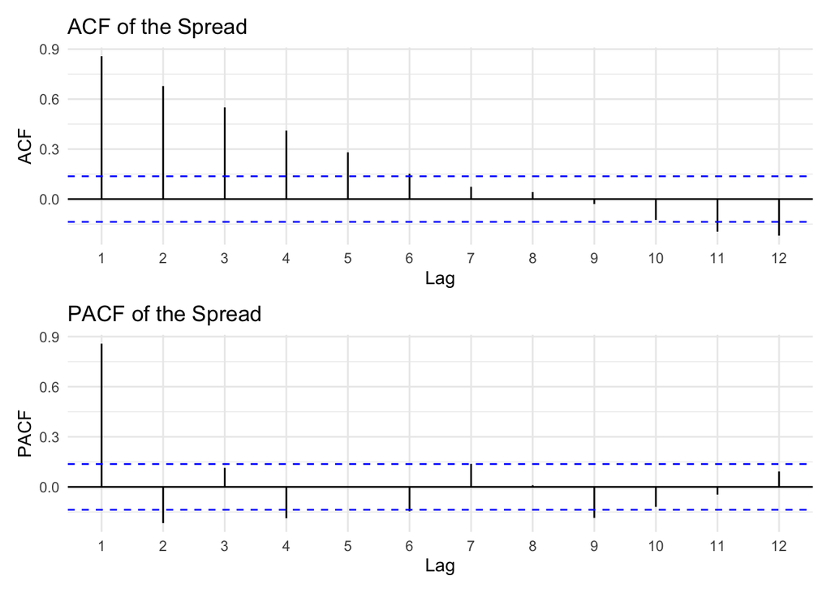

Figure 4: ACF and PACF of the Spread

```r
p_acf_spread/p_pacf_spread
```

### Replicate Table 2.4 (p.91)

Estimate the models.

```r
# estimate the models
arima700 <- arima(df_model$spread, order = c(7,0,0))
arima600 <- arima(df_model$spread, order = c(6,0,0))
arima200 <- arima(df_model$spread, order = c(2,0,0))
wierd_mod1 <- arma(df_model$spread, lag = list(ar = c(1, 2, 7)))
arima101 <- arima(df_model$spread, order = c(1,0,1))
arima201 <- arima(df_model$spread, order = c(2,0,1))
wierd_mod2 <- arma(df_model$spread, lag = list(ar = c(1, 2), ma = c(1,7)))

# create list of models to iterate over them
model_list <- list(arima700, arima600, arima200, wierd_mod1, arima101, arima201, wierd_mod2)
```

Calculate additional metrics: $AIC$, $SBC$, $SSR$, $Q(4)$, $Q(8)$, $Q(12)$.

```r
n_models <- length(model_list)

# helper function to calculate BIC from AIC
my_bic <- function(model) {
  aic <- summary(model)$aic
  n <- length(df_model$spread)
  p <- if (class(model) == "arma") length(summary(model)$coef[,1]) else length(summary(model)$coef)
  p*log(n) + summary(model)$aic - 2*p
}

# create data frame for metrics
df_metrics <- data.frame("SSR" = rep(0, n_models),
                         "AIC" = rep(0, n_models),
                         "SBC" = rep(0, n_models),
                         "Q4" = rep(0, n_models),
                         "Q8" = rep(0, n_models),
                         "Q12" = rep(0, n_models))

for (i in 1:n_models) {
  df_metrics$SSR[i] <- sum(na.omit(model_list[[i]]$residuals)^2)
  df_metrics$AIC[i] <- summary(model_list[[i]])$aic
  df_metrics$SBC[i] <- my_bic(model_list[[i]])
  df_metrics$Q4[i] <- Box.test(na.omit(model_list[[i]]$residuals),
                                     lag = 4, type = "Ljung")$statistic
  df_metrics$Q8[i] <- Box.test(na.omit(model_list[[i]]$residuals),
                               lag = 8, type = "Ljung")$statistic
  df_metrics$Q12[i] <- Box.test(na.omit(model_list[[i]]$residuals),
                                lag = 12, type = "Ljung")$statistic
}
```

Form a replica of Table 2.4.

```r
# set column and row names
col_names <- c("AR(7)", "AR(6)", "AR(2)", "p = 1, 2, 7", "ARMA(1,1)", "ARMA(2,1)", "p = 2, ma = (1,7)")
row_names <- c("a0", "a1", "a2", "a3", "a4", "a5", "a6", "a7", "b1", "b7")

# create an empty table for coefficients
df_coef <- matrix(nrow = 10, ncol = 7)

# fill matrix with coefficients
# ar coefficients
df_coef[2:8,1] <- summary(arima700)$coef[1:7]
df_coef[2:7,2] <- summary(arima600)$coef[1:6]
df_coef[2:3,3] <- summary(arima200)$coef[1:2]
df_coef[2:3,4] <- summary(wierd_mod1)$coef[1:2,1]
df_coef[2,5] <- summary(arima101)$coef[1]
df_coef[2:3,6] <- summary(arima201)$coef[1:2]
df_coef[2:3,7] <- summary(wierd_mod2)$coef[1:2,1]
# intercepts
df_coef[1,1] <- summary(arima700)$coef[8]
df_coef[1,2] <- summary(arima600)$coef[7]
df_coef[1,3] <- summary(arima200)$coef[3]
df_coef[1,4] <- summary(wierd_mod1)$coef[4,1]/(1-sum(summary(wierd_mod1)$coef[1:3,1]))
df_coef[1,5] <- summary(arima101)$coef[3]
df_coef[1,6] <- summary(arima201)$coef[4]
df_coef[1,7] <- summary(wierd_mod2)$coef[5,1]/(1-sum(summary(wierd_mod1)$coef[1:2,1])) - sum(summary(wierd_mod2)$coef[3:4,1])
# ma coefficients
df_coef[9,5] <- summary(arima101)$coef[2]
df_coef[9,6] <- summary(arima201)$coef[3]
df_coef[9:10,7] <- summary(wierd_mod2)$coef[3:4,1]

# set column and row names
colnames(df_coef) <- col_names # set new column names
rownames(df_coef) <- row_names # set new row names

# transform a table of metrics
df_metrics <- t(df_metrics) # transpose
colnames(df_metrics) <- col_names # set new column names

# create the final table
df_summary <- rbind(df_coef, df_metrics)
df_summary_round <- round(df_summary, 2) # round values to 2 decimal places
```

```r
# print the final table
options(knitr.kable.NA = '') # don't print NA's
kable(df_summary_round)
```

|  | AR(7) | AR(6) | AR(2) | p = 1, 2, 7 | ARMA(1,1) | ARMA(2,1) | p = 2, ma = (1,7) |
| --- | --- | --- | --- | --- | --- | --- | --- |
| a0 | 1.21 | 1.21 | 1.20 | 1.22 | 1.20 | 1.20 | 1.24 |
| a1 | 1.11 | 1.09 | 1.04 | 1.04 | 0.76 | 0.42 | 0.35 |
| a2 | -0.45 | -0.42 | -0.22 | -0.20 |  | 0.32 | 0.40 |
| a3 | 0.39 | 0.36 |  |  |  |  |  |
| a4 | -0.29 | -0.24 |  |  |  |  |  |
| a5 | 0.21 | 0.16 |  |  |  |  |  |
| a6 | -0.29 | -0.15 |  |  |  |  |  |
| a7 | 0.13 |  |  |  |  |  |  |
| b1 |  |  |  |  | 0.38 | 0.70 | 0.78 |
| b7 |  |  |  |  |  |  | -0.14 |
| SSR | 43.85 | 44.66 | 48.00 | 47.73 | 46.94 | 45.76 | 43.55 |
| AIC | 285.48 | 287.07 | 293.57 | 299.13 | 289.07 | 285.94 | 282.38 |
| SBC | 312.06 | 310.33 | 303.54 | 312.42 | 299.04 | 299.23 | 299.00 |
| Q4 | 0.17 | 0.29 | 8.99 | 8.26 | 6.61 | 1.24 | 0.62 |
| Q8 | 5.55 | 10.60 | 21.44 | 21.50 | 18.25 | 12.14 | 2.49 |
| Q12 | 13.16 | 16.17 | 28.81 | 27.94 | 24.01 | 18.81 | 10.79 |

Table 1: Estimates of the Interest Rate Spread

**End of the suggested solution.**